# ADS 506 Final Team Project: U.S. Retail Sales Forecasting

## 5.2 Exponential Smoothing (ETS) [Implemented: Mia]

> **Lead / Owner:** Mia Arnold  
> **Model Class:** `fable::ETS()` State Space Models  
> **Objective:** Evaluate automatic ETS model selection ($\text{AIC}_c$) against candidate models with additive vs. multiplicative errors, damped trends, and multiplicative seasonality.

> **Transformation Guidance:**
> - **Multiplicative vs. Additive ETS:** Exponential smoothing handles heteroscedasticity (expanding seasonal variance) natively through **multiplicative error and seasonal components** (e.g., $ETS(M,A,M)$ or $ETS(M,A_d,M)$). Per Hyndman & Athanasopoulos (2021, Ch. 8), an ETS model with multiplicative components often removes the need for a prior Box-Cox transformation.
> - **Candidate Strategies:** Fit and compare multiplicative models on raw nominal data against additive models on Box-Cox transformed data (using Guerrero optimal $\lambda$) and log-transformed data.

```r
    # Strategy 1: Multiplicative components on raw nominal dollars (native variance handling)
fits_ets <- train_data |>
  model(
    ets_auto_multiplicative = ETS(sales_nominal),
    ets_mam                 = ETS(sales_nominal ~ error("M") + trend("A") + season("M")),
    ets_damped              = ETS(sales_nominal ~ error("M") + trend("Ad") + season("M")),

    # Strategy 2: Strictly additive components on Log transformed sales
    ets_log_additive        = ETS(log(sales_nominal) ~ error("A") + trend("A") + season("A")),
    ets_log_damped          = ETS(log(sales_nominal) ~ error("A") + trend("Ad") + season("A"))
  )

    # Strategy 3: Fit vertical-specific Guerrero Box-Cox Additive ETS per key
train_lambdas <- train_data |>
  features(sales_nominal, features = guerrero)

fits_ets_bc <- train_data |>
  left_join(train_lambdas, by = "vertical") |>
  group_split(vertical) |>
  map(\(df) {
    lam <- unique(df$lambda_guerrero)
    df |>
      model(
        ets_boxcox_add    = ETS(box_cox(sales_nominal, lam) ~ error("A") + trend("A")  + season("A")),
        ets_boxcox_damped = ETS(box_cox(sales_nominal, lam) ~ error("A") + trend("Ad") + season("A"))
      )
  }) |>
  reduce(bind_rows)

    # Combine all ETS models into one mable
fits_ets_all <- fits_ets |>
  left_join(fits_ets_bc, by = "vertical")
```

```r
# Model fit statistics (AICc, AIC, BIC) across ETS specifications
glance(fits_ets_all) |>
  select(vertical, .model, AICc, AIC, BIC) |>
  mutate(across(c(AICc, AIC, BIC), \(x) round(x, 1))) |>
  arrange(vertical, AICc) |>
  knitr::kable(caption = "ETS Model Candidates: Goodness-of-Fit Information Criteria (Pre-2024 Training Set)")
```

ETS Model Candidates: Goodness-of-Fit Information Criteria (Pre-2024 Training Set)

| vertical | .model | AICc | AIC | BIC |
| --- | --- | --- | --- | --- |
| building | ets_boxcox_add | -1141.4 | -1143.1 | -1075.9 |
| building | ets_boxcox_damped | -1140.2 | -1142.0 | -1070.9 |
| building | ets_log_additive | -156.1 | -157.8 | -90.6 |
| building | ets_log_damped | -149.4 | -151.2 | -80.1 |
| building | ets_auto_multiplicative | 7550.8 | 7548.9 | 7620.0 |
| building | ets_damped | 7550.8 | 7548.9 | 7620.0 |
| building | ets_mam | 7555.0 | 7553.4 | 7620.5 |
| clothing | ets_log_damped | 651.5 | 649.6 | 720.7 |
| clothing | ets_log_additive | 657.0 | 655.3 | 722.5 |
| clothing | ets_boxcox_add | 3841.5 | 3839.9 | 3907.0 |
| clothing | ets_boxcox_damped | 3844.4 | 3842.6 | 3913.7 |
| clothing | ets_auto_multiplicative | 7758.4 | 7756.7 | 7823.9 |
| clothing | ets_mam | 7758.4 | 7756.7 | 7823.9 |
| clothing | ets_damped | 7760.2 | 7758.3 | 7829.5 |
| health | ets_log_additive | -585.0 | -586.7 | -519.5 |
| health | ets_log_damped | -570.5 | -572.4 | -501.3 |
| health | ets_boxcox_add | 2095.8 | 2094.1 | 2161.3 |
| health | ets_boxcox_damped | 2112.2 | 2110.4 | 2181.5 |
| health | ets_auto_multiplicative | 6910.7 | 6909.0 | 6976.2 |
| health | ets_mam | 6910.7 | 6909.0 | 6976.2 |
| health | ets_damped | 6921.9 | 6920.1 | 6991.2 |
| macro_retail | ets_log_damped | -325.8 | -327.7 | -256.5 |
| macro_retail | ets_log_additive | -293.8 | -295.4 | -228.3 |
| macro_retail | ets_boxcox_add | 2284.5 | 2282.8 | 2350.0 |
| macro_retail | ets_boxcox_damped | 2293.5 | 2291.6 | 2362.7 |
| macro_retail | ets_auto_multiplicative | 8061.1 | 8059.4 | 8126.5 |
| macro_retail | ets_mam | 8061.1 | 8059.4 | 8126.5 |
| macro_retail | ets_damped | 8066.1 | 8064.2 | 8135.3 |

```r
# Generate forecasts and compare out-of-sample test RMSE:
fc_ets <- fits_ets_all |> forecast(new_data = test_data)

ets_accuracy <- accuracy(fc_ets, retail_ts) |>
  select(vertical, .model, RMSE, MAE, MAPE, MASE) |>
  arrange(vertical, RMSE)

ets_accuracy |>
  knitr::kable(digits = c(0, 0, 1, 1, 2, 3),
               caption = "Out-of-Sample Accuracy of ETS Candidate Models (2024–2026 Test Holdout)")
```

Out-of-Sample Accuracy of ETS Candidate Models (2024–2026 Test Holdout)

| vertical | .model | RMSE | MAE | MAPE | MASE |
| --- | --- | --- | --- | --- | --- |
| building | ets_auto_multiplicative | 1502.5 | 1166.8 | 2.67 | 0.718 |
| building | ets_damped | 1502.5 | 1166.8 | 2.67 | 0.718 |
| building | ets_log_damped | 1929.2 | 1454.2 | 3.31 | 0.894 |
| building | ets_mam | 2018.6 | 1586.7 | 3.68 | 0.976 |
| building | ets_boxcox_damped | 2153.3 | 1645.5 | 3.71 | 1.012 |
| building | ets_log_additive | 3664.0 | 3168.7 | 7.25 | 1.949 |
| building | ets_boxcox_add | 4824.0 | 4111.6 | 9.30 | 2.529 |
| clothing | ets_auto_multiplicative | 956.2 | 723.4 | 2.89 | 0.689 |
| clothing | ets_mam | 956.2 | 723.4 | 2.89 | 0.689 |
| clothing | ets_boxcox_damped | 1119.7 | 939.4 | 3.99 | 0.895 |
| clothing | ets_log_damped | 1169.7 | 895.9 | 3.51 | 0.853 |
| clothing | ets_boxcox_add | 1299.0 | 1113.6 | 4.97 | 1.061 |
| clothing | ets_log_additive | 1936.7 | 1455.5 | 5.72 | 1.386 |
| clothing | ets_damped | 2090.6 | 1724.9 | 6.95 | 1.643 |
| health | ets_damped | 1534.5 | 1270.6 | 3.29 | 1.371 |
| health | ets_log_damped | 1566.4 | 1299.7 | 3.37 | 1.403 |
| health | ets_boxcox_damped | 1579.4 | 1287.7 | 3.33 | 1.390 |
| health | ets_auto_multiplicative | 1584.6 | 1358.9 | 3.54 | 1.467 |
| health | ets_mam | 1584.6 | 1358.9 | 3.54 | 1.467 |
| health | ets_log_additive | 1617.4 | 1390.6 | 3.64 | 1.501 |
| health | ets_boxcox_add | 1623.4 | 1380.9 | 3.58 | 1.490 |
| macro_retail | ets_boxcox_add | 2473.8 | 2040.8 | 1.98 | 0.676 |
| macro_retail | ets_auto_multiplicative | 2912.1 | 2264.7 | 2.12 | 0.750 |
| macro_retail | ets_mam | 2912.1 | 2264.7 | 2.12 | 0.750 |
| macro_retail | ets_log_damped | 3210.5 | 2565.3 | 2.40 | 0.850 |
| macro_retail | ets_damped | 3442.1 | 2825.6 | 2.64 | 0.936 |
| macro_retail | ets_log_additive | 3480.2 | 2789.7 | 2.67 | 0.925 |
| macro_retail | ets_boxcox_damped | 4927.5 | 4215.3 | 3.89 | 1.397 |

## 5.3 Time Series Linear Models (TSLM) Regression & COVID Shock Modeling [Implemented: Mia & Jordan]

> **Lead / Owners:** Mia Arnold & Jordan Blackman  
> **Model Class:** `fable::TSLM()`  
> **Objective:** Construct linear regression models using deterministic trend, monthly seasonal dummies, and exogenous economic regressors (e.g., CPI price index and COVID intervention dummies).

> **Transformation Guidance:**
> - **Homoscedasticity Requirement:** Ordinary Least Squares (OLS) regression assumes errors have constant variance. Fitting a linear regression directly to untransformed nominal sales violates OLS assumptions. Always model either **Box-Cox transformed sales** or **natural log sales**.
> - **Econometric Story with CPI:** Introducing $\log(\text{CPI})$ as an explanatory regressor alongside trend and monthly seasonal dummies allows us to estimate the price elasticity of retail sales across defensive vs. cyclical verticals.

```r
# TSLM requires variance stabilization (Box-Cox or log) to satisfy OLS homoscedasticity:
fits_tslm <- train_data |>
  model(
    # Model 1: Log-transformed linear trend + monthly seasonal dummies
    tslm_log_trend_season = TSLM(log(sales_nominal) ~ trend() + season()),

    # Model 2: Piecewise trend with knot at COVID onset + lockdown pulse indicator (March-May 2020)
    tslm_log_piecewise_covid = TSLM(
      log(sales_nominal) ~ trend(knots = yearmonth("2020 Mar")) + season() +
        I(Month >= yearmonth("2020 Mar") & Month <= yearmonth("2020 May"))
    ),

    # Model 3: Augmented TSLM with CPI explanatory regressor (log-log price elasticity)
    tslm_with_cpi = TSLM(log(sales_nominal) ~ trend() + season() + log(cpi)),

    # Model 4: Augmented TSLM with CPI + piecewise COVID trend & lockdown pulse indicator
    tslm_cpi_piecewise_covid = TSLM(
      log(sales_nominal) ~ trend(knots = yearmonth("2020 Mar")) + season() + log(cpi) +
        I(Month >= yearmonth("2020 Mar") & Month <= yearmonth("2020 May"))
    )
  )

# Model 5: Fit vertical-specific Guerrero Box-Cox lambdas
fits_tslm_bc <- train_data |>
  left_join(train_lambdas, by = "vertical") |>
  group_split(vertical) |>
  map(\(df) {
    lam <- unique(df$lambda_guerrero)
    df |>
      model(
        tslm_boxcox = TSLM(box_cox(sales_nominal, lam) ~ trend() + season())
      )
  }) |>
  reduce(bind_rows)

# Combine all TSLM models into one mable
fits_tslm_all <- fits_tslm |>
  left_join(fits_tslm_bc, by = "vertical")
```

```r
# Extract estimated percentage impact of COVID lockdown across verticals
covid_lockdown_effects <- tidy(fits_tslm_all) |>
  filter(.model == "tslm_log_piecewise_covid",
         str_detect(term, "2020 Mar.*2020 May")) |>
  transmute(
    Vertical = vertical,
    `Coefficient (beta)` = round(estimate, 3),
    `Std Error` = round(std.error, 3),
    `t-statistic` = round(statistic, 2),
    `p-value` = format.pval(p.value, digits = 3, eps = 0.001),
    `Estimated Sales Impact (%)` = scales::percent(exp(estimate) - 1, accuracy = 0.1)
  )

covid_lockdown_effects |>
  knitr::kable(caption = "Estimated COVID-19 lockdown impact across retail verticals from TSLM piecewise intervention model")
```

Estimated COVID-19 lockdown impact across retail verticals from TSLM piecewise intervention model

| Vertical | Coefficient (beta) | Std Error | t-statistic | p-value | Estimated Sales Impact (%) |
| --- | --- | --- | --- | --- | --- |
| building | -0.016 | 0.075 | -0.21 | 0.836 | -1.5% |
| clothing | -1.352 | 0.054 | -25.03 | <0.001 | -74.1% |
| health | -0.206 | 0.052 | -3.96 | <0.001 | -18.6% |
| macro_retail | -0.276 | 0.049 | -5.60 | <0.001 | -24.1% |

```r
fc_tslm <- fits_tslm_all |> forecast(new_data = test_data)

tslm_accuracy <- accuracy(fc_tslm, retail_ts) |>
  select(vertical, .model, RMSE, MAE, MAPE, MASE) |>
  arrange(vertical, RMSE)

tslm_accuracy |>
  knitr::kable(digits = c(0, 0, 1, 1, 2, 3),
               caption = "TSLM candidate models: 2024-2026 test accuracy across retail verticals")
```

TSLM candidate models: 2024-2026 test accuracy across retail verticals

| vertical | .model | RMSE | MAE | MAPE | MASE |
| --- | --- | --- | --- | --- | --- |
| building | tslm_log_trend_season | 1665.2 | 1258.7 | 2.93 | 0.774 |
| building | tslm_boxcox | 2300.9 | 1759.8 | 4.00 | 1.082 |
| building | tslm_with_cpi | 6350.4 | 5800.4 | 13.31 | 3.567 |
| building | tslm_cpi_piecewise_covid | 12464.4 | 11761.1 | 27.11 | 7.233 |
| building | tslm_log_piecewise_covid | 13372.6 | 12520.3 | 28.85 | 7.700 |
| clothing | tslm_boxcox | 1031.3 | 860.6 | 3.71 | 0.820 |
| clothing | tslm_log_trend_season | 1796.7 | 1287.0 | 5.08 | 1.226 |
| clothing | tslm_log_piecewise_covid | 2541.5 | 2171.2 | 8.84 | 2.068 |
| clothing | tslm_cpi_piecewise_covid | 3013.5 | 2530.3 | 10.24 | 2.410 |
| clothing | tslm_with_cpi | 5301.0 | 4945.1 | 20.08 | 4.710 |
| health | tslm_boxcox | 1819.5 | 1469.5 | 3.79 | 1.586 |
| health | tslm_log_trend_season | 3152.0 | 2747.8 | 7.39 | 2.966 |
| health | tslm_log_piecewise_covid | 5902.7 | 5572.4 | 14.50 | 6.014 |
| health | tslm_cpi_piecewise_covid | 6816.4 | 6321.1 | 16.40 | 6.822 |
| health | tslm_with_cpi | 8018.1 | 7734.8 | 20.57 | 8.348 |
| macro_retail | tslm_cpi_piecewise_covid | 3030.5 | 2238.5 | 2.10 | 0.742 |
| macro_retail | tslm_boxcox | 3246.9 | 2723.1 | 2.56 | 0.902 |
| macro_retail | tslm_log_piecewise_covid | 3644.6 | 2927.2 | 2.73 | 0.970 |
| macro_retail | tslm_log_trend_season | 4060.5 | 3256.5 | 3.04 | 1.079 |
| macro_retail | tslm_with_cpi | 17234.3 | 16640.5 | 15.72 | 5.515 |

## 5.4 Seasonal ARIMA & Box-Jenkins [Implemented: Ramin]

> **Lead / Owner:** Ramin Fazli  
> **Model Class:** `fable::ARIMA()` (pure univariate seasonal ARIMA)  
> **Objective:** Test stationarity on the log scale, identify candidate $(p,d,q)(P,D,Q)_{12}$ orders from ACF/PACF plots, compare automated and manual specifications, check residuals with the Ljung-Box test, and evaluate out-of-sample accuracy against the baselines.

### 5.4.1 Stationarity on the Log Scale

ARIMA is fitted to `log(sales_nominal)` to stabilize the growing seasonal swings before differencing, since differencing cannot fix non-constant variance (Hyndman & Athanasopoulos, 2021, Ch. 9). The diagnostics in Section 4.8 tested raw sales; the table below repeats them on the log scale used for modeling, using the training period only.

```r
arima_stationarity <- train_data |>
  features(log(sales_nominal), unitroot_nsdiffs) |>
  left_join(
    train_data |>
      group_by_key() |>
      mutate(log_d12 = difference(log(sales_nominal), 12)) |>
      ungroup() |>
      features(log_d12, list(unitroot_ndiffs, unitroot_kpss)),
    by = "vertical"
  )

arima_stationarity |>
  transmute(
    Vertical = vertical,
    `Seasonal diff (D)` = nsdiffs,
    `First diff (d) after D = 1` = ndiffs,
    `KPSS stat after D = 1` = round(kpss_stat, 3),
    `KPSS p-value` = round(kpss_pvalue, 3)
  ) |>
  knitr::kable(caption = "Log-scale differencing diagnostics (training data, 1992-2023)")
```

Log-scale differencing diagnostics (training data, 1992-2023)

| Vertical | Seasonal diff (D) | First diff (d) after D = 1 | KPSS stat after D = 1 | KPSS p-value |
| --- | --- | --- | --- | --- |
| building | 1 | 1 | 0.470 | 0.048 |
| clothing | 1 | 0 | 0.051 | 0.100 |
| health | 1 | 1 | 1.755 | 0.010 |
| macro_retail | 1 | 1 | 0.489 | 0.044 |

On the log scale every series needs one seasonal difference. Clothing is stationary after that, while Health, Building, and the Macro total also need a first difference (for Building and Macro the KPSS result is borderline, p just under 0.05).

### 5.4.2 Identifying Candidate Orders (ACF / PACF)

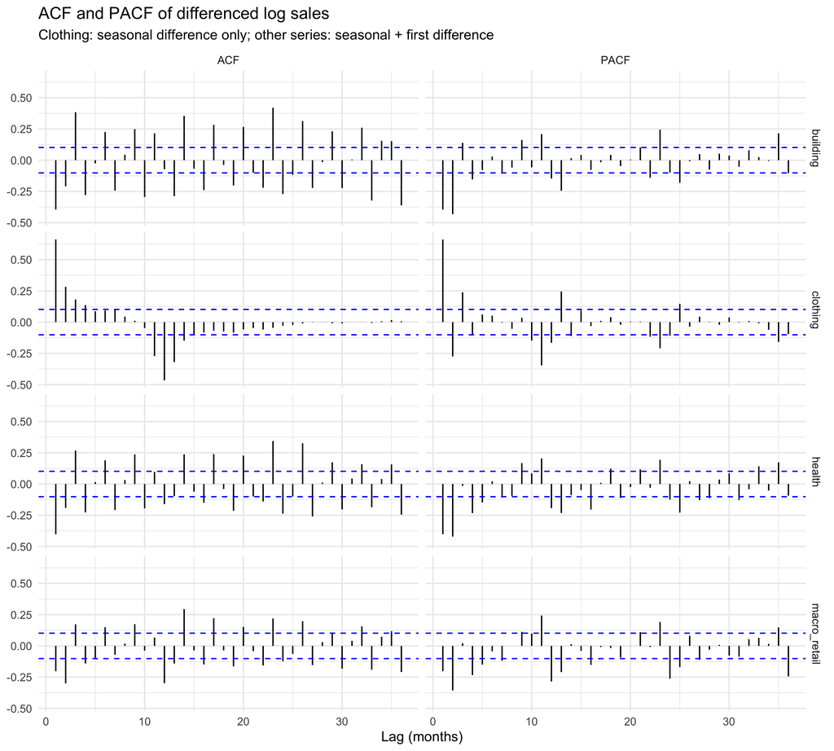

```r
arima_differenced <- train_data |>
  group_by_key() |>
  mutate(
    d_series = if_else(
      vertical == "clothing",
      difference(log(sales_nominal), 12),
      difference(difference(log(sales_nominal), 12), 1)
    )
  ) |>
  ungroup()

acf_tbl  <- arima_differenced |> ACF(d_series, lag_max = 36) |> as_tibble() |> mutate(type = "ACF", value = acf)
pacf_tbl <- arima_differenced |> PACF(d_series, lag_max = 36) |> as_tibble() |> mutate(type = "PACF", value = pacf)
n_obs <- arima_differenced |> as_tibble() |> filter(!is.na(d_series)) |> count(vertical)

bind_rows(acf_tbl, pacf_tbl) |>
  mutate(lag = as.numeric(lag)) |>
  left_join(n_obs, by = "vertical") |>
  ggplot(aes(lag, value)) +
  geom_segment(aes(xend = lag, yend = 0)) +
  geom_hline(aes(yintercept = 1.96 / sqrt(n)), linetype = "dashed", colour = "blue") +
  geom_hline(aes(yintercept = -1.96 / sqrt(n)), linetype = "dashed", colour = "blue") +
  facet_grid(vertical ~ type) +
  labs(title = "ACF and PACF of differenced log sales",
       subtitle = "Clothing: seasonal difference only; other series: seasonal + first difference",
       x = "Lag (months)", y = NULL)
```

For Health, Building, and Macro, the differenced series show a clear negative spike at lag 1 (and at lag 2 in the PACF), and Health and Macro also show negative autocorrelation at lag 12. This points to low-order AR or MA terms with a seasonal MA(1). For Clothing, the PACF cuts off after one or two lags and the ACF has a clear negative spike at lag 12, which points to an AR(2) or ARMA(1,1) with a seasonal MA(1). These patterns give the manual candidates below; the airline model $(0,1,1)(0,1,1)_{12}$ is included as a classic retail benchmark.

### 5.4.3 Candidate Models

```r
arima_lambdas <- train_data |> features(sales_nominal, features = guerrero)

fit_arima_vertical <- function(df) {
  lam <- arima_lambdas$lambda_guerrero[arima_lambdas$vertical == unique(df$vertical)]
  if (unique(df$vertical) == "clothing") {
    df |> model(
      auto_log    = ARIMA(log(sales_nominal)),
      auto_boxcox = ARIMA(box_cox(sales_nominal, lam)),
      manual_a    = ARIMA(log(sales_nominal) ~ 1 + pdq(2, 0, 0) + PDQ(0, 1, 1)),
      manual_b    = ARIMA(log(sales_nominal) ~ 1 + pdq(1, 0, 1) + PDQ(0, 1, 1)),
      airline     = ARIMA(log(sales_nominal) ~ 0 + pdq(0, 1, 1) + PDQ(0, 1, 1))
    )
  } else {
    df |> model(
      auto_log    = ARIMA(log(sales_nominal)),
      auto_boxcox = ARIMA(box_cox(sales_nominal, lam)),
      manual_a    = ARIMA(log(sales_nominal) ~ 0 + pdq(2, 1, 0) + PDQ(0, 1, 1)),
      manual_b    = ARIMA(log(sales_nominal) ~ 0 + pdq(0, 1, 2) + PDQ(0, 1, 1)),
      airline     = ARIMA(log(sales_nominal) ~ 0 + pdq(0, 1, 1) + PDQ(0, 1, 1))
    )
  }
}

fits_arima <- train_data |>
  group_split(vertical) |>
  map(fit_arima_vertical) |>
  reduce(bind_rows)

fc_arima <- fits_arima |> forecast(new_data = test_data)
```

```r
# Ljung-Box on innovation residuals (lag 24 = 2 seasonal cycles; dof = number of ARMA terms)
arma_terms <- tidy(fits_arima) |>
  filter(str_detect(term, "^(ar|ma|sar|sma)[0-9]")) |>
  count(vertical, .model, name = "dof")

arima_lb <- augment(fits_arima) |>
  as_tibble() |>
  filter(!is.na(.innov)) |>
  left_join(arma_terms, by = c("vertical", ".model")) |>
  group_by(vertical, .model) |>
  summarise(lb_pvalue = Box.test(.innov, lag = 24, type = "Ljung-Box", fitdf = first(dof))$p.value,
            .groups = "drop")

arima_specs <- fits_arima |>
  pivot_longer(-vertical, names_to = ".model", values_to = "fit") |>
  as_tibble() |>
  mutate(Specification = map_chr(fit, format)) |>
  select(vertical, .model, Specification)

arima_accuracy <- accuracy(fc_arima, retail_ts) |>
  select(vertical, .model, RMSE, MAE, MAPE, MASE)

arima_summary <- arima_specs |>
  left_join(glance(fits_arima) |> select(vertical, .model, AICc), by = c("vertical", ".model")) |>
  left_join(arima_lb, by = c("vertical", ".model")) |>
  left_join(arima_accuracy, by = c("vertical", ".model")) |>
  arrange(vertical, RMSE)

arima_summary |>
  mutate(AICc = if_else(.model == "auto_boxcox", NA_real_, AICc)) |>
  knitr::kable(digits = c(0, 0, 0, 1, 3, 1, 1, 2, 3),
               caption = "Seasonal ARIMA candidates: specification, training AICc, Ljung-Box p-value, and 2024-2026 test accuracy (sorted by test RMSE). AICc is omitted for Box-Cox models because it is not comparable across transformations.")
```

Seasonal ARIMA candidates: specification, training AICc, Ljung-Box p-value, and 2024-2026 test accuracy (sorted by test RMSE). AICc is omitted for Box-Cox models because it is not comparable across transformations.

| vertical | .model | Specification | AICc | lb_pvalue | RMSE | MAE | MAPE | MASE |
| --- | --- | --- | --- | --- | --- | --- | --- | --- |
| building | auto_log | ARIMA(2,1,1)(0,1,2)[12] | -1386.1 | 0.000 | 3016.6 | 2500.4 | 5.73 | 1.538 |
| building | auto_boxcox | ARIMA(2,1,1)(0,1,2)[12] | NA | 0.000 | 3415.7 | 2789.3 | 6.33 | 1.715 |
| building | manual_a | ARIMA(2,1,0)(0,1,1)[12] | -1343.3 | 0.000 | 3753.8 | 3252.3 | 7.54 | 2.000 |
| building | manual_b | ARIMA(0,1,2)(0,1,1)[12] | -1306.3 | 0.000 | 4050.1 | 3528.2 | 8.15 | 2.170 |
| building | airline | ARIMA(0,1,1)(0,1,1)[12] | -1306.8 | 0.000 | 4146.7 | 3619.7 | 8.36 | 2.226 |
| clothing | auto_boxcox | ARIMA(1,0,3)(0,1,1)[12] w/ drift | NA | 0.492 | 1105.3 | 870.5 | 3.58 | 0.829 |
| clothing | auto_log | ARIMA(1,0,3)(0,1,1)[12] w/ drift | -612.7 | 0.682 | 1284.4 | 979.2 | 4.00 | 0.933 |
| clothing | manual_a | ARIMA(2,0,0)(0,1,1)[12] w/ drift | -591.1 | 0.007 | 1309.8 | 1019.1 | 4.18 | 0.971 |
| clothing | manual_b | ARIMA(1,0,1)(0,1,1)[12] w/ drift | -605.0 | 0.147 | 1322.2 | 1006.0 | 4.12 | 0.958 |
| clothing | airline | ARIMA(0,1,1)(0,1,1)[12] | -520.1 | 0.000 | 3270.6 | 2681.1 | 10.65 | 2.554 |
| health | manual_a | ARIMA(2,1,0)(0,1,1)[12] | -1733.8 | 0.000 | 1560.1 | 1335.0 | 3.48 | 1.441 |
| health | auto_log | ARIMA(5,1,0)(0,1,1)[12] | -1758.4 | 0.000 | 1583.7 | 1359.0 | 3.53 | 1.467 |
| health | manual_b | ARIMA(0,1,2)(0,1,1)[12] | -1722.4 | 0.000 | 1637.7 | 1398.9 | 3.63 | 1.510 |
| health | auto_boxcox | ARIMA(2,1,2)(0,1,2)[12] | NA | 0.000 | 1638.9 | 1350.7 | 3.49 | 1.458 |
| health | airline | ARIMA(0,1,1)(0,1,1)[12] | -1720.8 | 0.000 | 1681.6 | 1432.3 | 3.72 | 1.546 |
| macro_retail | auto_boxcox | ARIMA(3,0,1)(0,1,1)[12] w/ drift | NA | 0.000 | 2339.5 | 1975.7 | 1.89 | 0.655 |
| macro_retail | manual_a | ARIMA(2,1,0)(0,1,1)[12] | -1493.9 | 0.000 | 2880.9 | 2290.5 | 2.19 | 0.759 |
| macro_retail | airline | ARIMA(0,1,1)(0,1,1)[12] | -1484.3 | 0.000 | 2930.1 | 2325.8 | 2.22 | 0.771 |
| macro_retail | manual_b | ARIMA(0,1,2)(0,1,1)[12] | -1492.1 | 0.000 | 3151.2 | 2485.8 | 2.38 | 0.824 |
| macro_retail | auto_log | ARIMA(4,1,1)(0,1,1)[12] | -1514.0 | 0.000 | 3174.1 | 2510.5 | 2.40 | 0.832 |

### 5.4.4 Model Selection & Residual Diagnostics

The model for each series is selected by **training AICc among the log-scale models**, so the choice does not depend on the test set. `auto_log` has the lowest AICc for all four series.

```r
arima_selected <- arima_summary |>
  filter(.model != "auto_boxcox") |>
  group_by(vertical) |>
  slice_min(AICc, n = 1, with_ties = FALSE) |>
  ungroup()

arima_selected |>
  left_join(baseline_accuracy |> group_by(vertical) |> slice_min(RMSE, n = 1) |>
              select(vertical, best_baseline = .model, baseline_RMSE = RMSE),
            by = "vertical") |>
  transmute(Vertical = vertical, Model = .model, Specification,
            `Ljung-Box p` = round(lb_pvalue, 3),
            `Test RMSE` = round(RMSE, 1), `Test MAPE` = round(MAPE, 2),
            `Best baseline` = best_baseline, `Baseline RMSE` = round(baseline_RMSE, 1)) |>
  knitr::kable(caption = "Selected seasonal ARIMA model per series vs. the best baseline")
```

Selected seasonal ARIMA model per series vs. the best baseline

| Vertical | Model | Specification | Ljung-Box p | Test RMSE | Test MAPE | Best baseline | Baseline RMSE |
| --- | --- | --- | --- | --- | --- | --- | --- |
| building | auto_log | ARIMA(2,1,1)(0,1,2)[12] | 0.000 | 3016.6 | 5.73 | snaive | 2152.7 |
| clothing | auto_log | ARIMA(1,0,3)(0,1,1)[12] w/ drift | 0.682 | 1284.4 | 4.00 | snaive | 1666.8 |
| health | auto_log | ARIMA(5,1,0)(0,1,1)[12] | 0.000 | 1583.7 | 3.53 | drift | 2697.6 |
| macro_retail | auto_log | ARIMA(4,1,1)(0,1,1)[12] | 0.000 | 3174.1 | 2.40 | snaive | 6278.8 |

```r
for (v in unique(arima_selected$vertical)) {
  m <- arima_selected$.model[arima_selected$vertical == v]
  p <- fits_arima |>
    filter(vertical == v) |>
    select(vertical, all_of(m)) |>
    gg_tsresiduals(lag_max = 36) +
    labs(title = paste0(v, ": residuals of ", m))
  print(p)
}
```

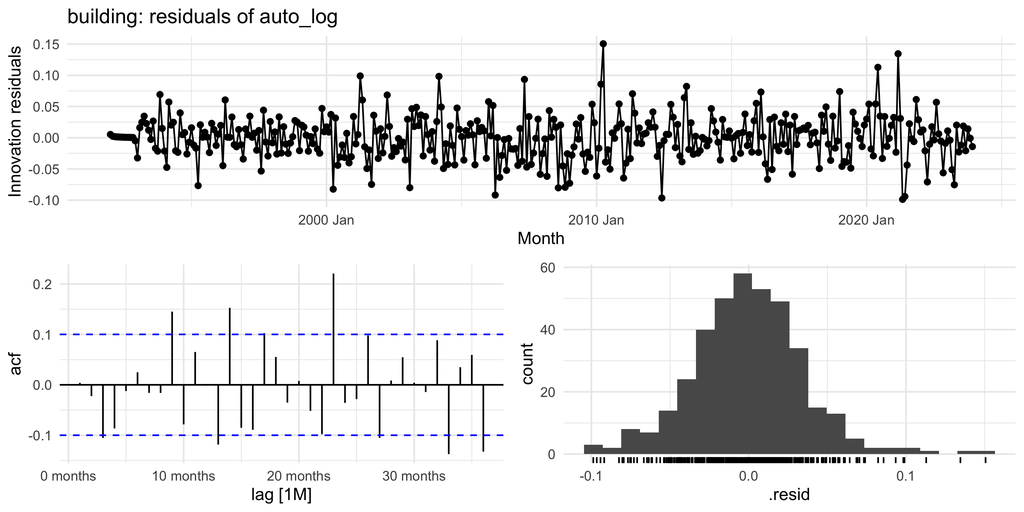

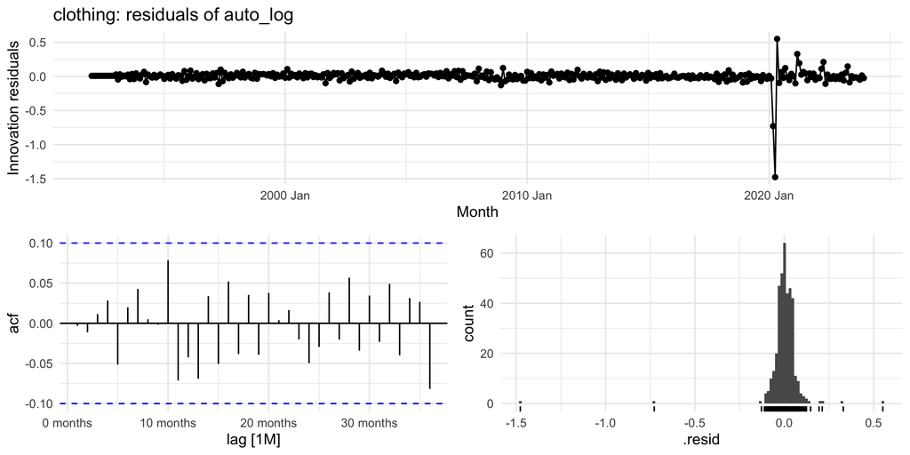

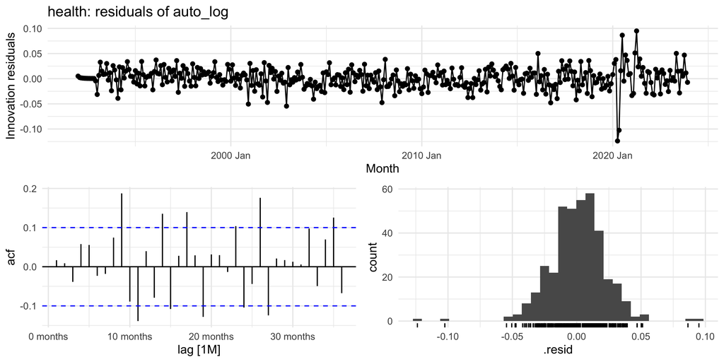

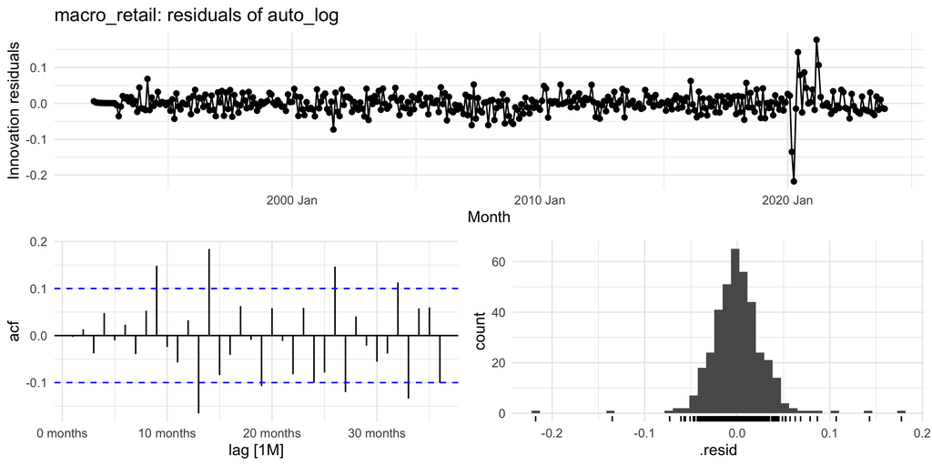

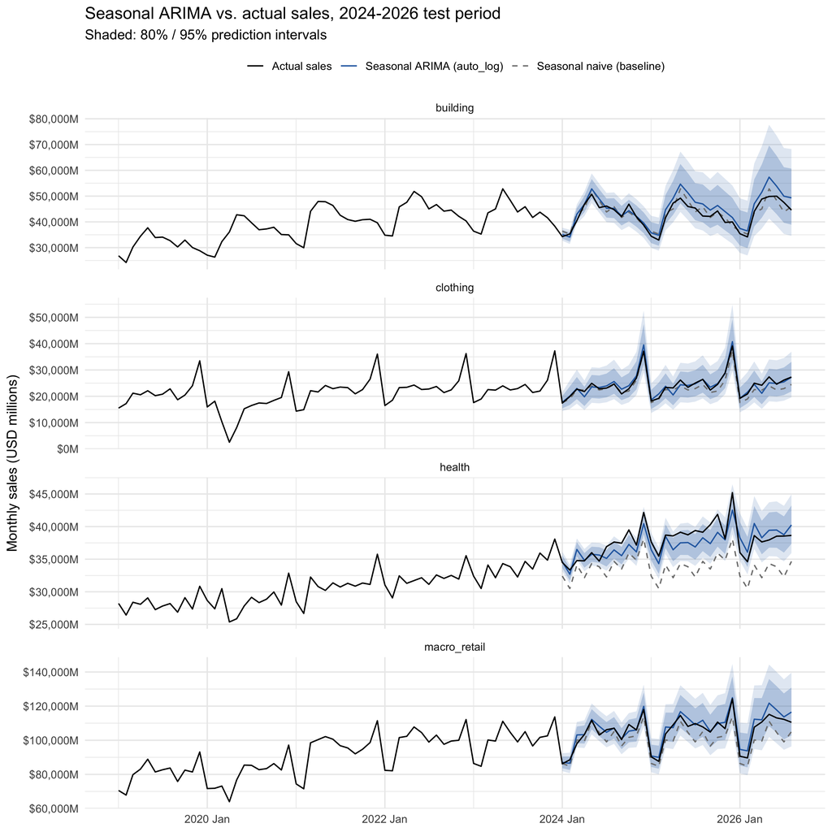

```r
arima_fc_plot <- fc_arima |>
  semi_join(arima_selected, by = c("vertical", ".model")) |>
  hilo(level = c(80, 95)) |>
  unpack_hilo(c(`80%`, `95%`)) |>
  as_tibble()

snaive_fc_plot <- fc_baseline |> filter(.model == "snaive") |> as_tibble()

ggplot() +
  geom_ribbon(data = arima_fc_plot, aes(Month, ymin = `95%_lower`, ymax = `95%_upper`), fill = "#2b6cb0", alpha = 0.15) +
  geom_ribbon(data = arima_fc_plot, aes(Month, ymin = `80%_lower`, ymax = `80%_upper`), fill = "#2b6cb0", alpha = 0.25) +
  geom_line(data = snaive_fc_plot, aes(Month, .mean, colour = "Seasonal naive (baseline)"), linetype = "dashed") +
  geom_line(data = arima_fc_plot, aes(Month, .mean, colour = "Seasonal ARIMA (auto_log)")) +
  geom_line(data = retail_ts |> as_tibble() |> filter(Month >= yearmonth("2019 Jan")),
            aes(Month, sales_nominal, colour = "Actual sales")) +
  scale_colour_manual(values = c("Actual sales" = "black", "Seasonal ARIMA (auto_log)" = "#2b6cb0",
                                 "Seasonal naive (baseline)" = "grey50"), name = NULL) +
  facet_wrap(vars(vertical), scales = "free_y", ncol = 1) +
  scale_y_continuous(labels = dollar_format(suffix = "M")) +
  labs(title = "Seasonal ARIMA vs. actual sales, 2024-2026 test period",
       subtitle = "Shaded: 80% / 95% prediction intervals",
       y = "Monthly sales (USD millions)", x = NULL) +
  theme(legend.position = "top")
```

**ARIMA interpretation.** The selected seasonal ARIMA beats the best baseline for three of the four series: Clothing (test RMSE 1,284 vs. 1,667 for seasonal naive), Health (1,584 vs. 2,698 for drift), and the Macro total (3,174 vs. 6,279). Building is the exception (3,017 vs. 2,153): sales went flat in 2025 and 2026, and the model carried the 2020-2022 growth forward, while seasonal naive simply repeated the previous year.

Two caveats matter for the report. First, only Clothing passes the Ljung-Box test; Building, Health, and Macro keep significant autocorrelation at several lags, and the pattern is already present before 2020, so it is not just the COVID shock. Their prediction intervals should therefore be read with caution. Second, the Box-Cox versions score better on the test set for Clothing and Macro, but they were not selected, because AICc cannot compare models on different transformations and the test set should not drive model choice. The leftover autocorrelation is addressed in the next section by adding trading-day regressors.

## 5.5 Dynamic Regression (ARIMAX), Fourier Terms & Ensembles [Implemented: Ramin]

> **Lead / Owner:** Ramin Fazli  
> **Model Class:** Regression with ARIMA errors (`ARIMA(y ~ xreg)`), dynamic harmonic regression (`fourier()`), and forecast combinations  
> **Objective:** Test whether calendar and price information improves on univariate ARIMA, compare Fourier seasonality against seasonal differencing, and evaluate simple forecast ensembles (Makridakis et al., 2022).

### 5.5.1 ARIMAX with Trading Days and CPI

The univariate models above leave significant autocorrelation in the residuals. Adding the trading-day regressors built in the Data Ingestion & Pipeline section lets the error model focus on true demand dynamics. We also test log CPI as a price regressor. **Note:** CPI forecasts are not available in practice, so the CPI models below use the *actual* 2024-2026 CPI (an ex-post evaluation); their accuracy is an upper bound on what a real forecast would achieve.

```r
fits_arimax <- train_data |>
  model(
    arimax_td       = ARIMA(log(sales_nominal) ~ td_mon + td_tue + td_wed + td_thu + td_fri + td_sat + days_in_month),
    arimax_td_covid = ARIMA(log(sales_nominal) ~ td_mon + td_tue + td_wed + td_thu + td_fri + td_sat + days_in_month +
                              I(Month >= yearmonth("2020 Mar") & Month <= yearmonth("2020 May"))),
    arimax_td_cpi   = ARIMA(log(sales_nominal) ~ td_mon + td_tue + td_wed + td_thu + td_fri + td_sat + days_in_month + log(cpi))
  )
```

### 5.5.2 Dynamic Harmonic Regression (Fourier Terms)

Instead of seasonal differencing, dynamic harmonic regression models the annual cycle with $K$ pairs of sine and cosine terms and leaves short-run dynamics to ARMA errors (Hyndman & Athanasopoulos, 2021, Ch. 10.5). We search $K = 1, \dots, 6$ with a first difference for trend and no seasonal ARIMA terms, select $K$ by AICc for each series, and then add trading days to the selected specification.

```r
fits_dhr_k <- train_data |>
  model(
    K1 = ARIMA(log(sales_nominal) ~ pdq(d = 1) + PDQ(0, 0, 0) + fourier(K = 1)),
    K2 = ARIMA(log(sales_nominal) ~ pdq(d = 1) + PDQ(0, 0, 0) + fourier(K = 2)),
    K3 = ARIMA(log(sales_nominal) ~ pdq(d = 1) + PDQ(0, 0, 0) + fourier(K = 3)),
    K4 = ARIMA(log(sales_nominal) ~ pdq(d = 1) + PDQ(0, 0, 0) + fourier(K = 4)),
    K5 = ARIMA(log(sales_nominal) ~ pdq(d = 1) + PDQ(0, 0, 0) + fourier(K = 5)),
    K6 = ARIMA(log(sales_nominal) ~ pdq(d = 1) + PDQ(0, 0, 0) + fourier(K = 6))
  )

dhr_k_choice <- glance(fits_dhr_k) |>
  group_by(vertical) |>
  slice_min(AICc, n = 1, with_ties = FALSE) |>
  ungroup() |>
  mutate(K = as.integer(str_remove(.model, "K")))

glance(fits_dhr_k) |>
  select(vertical, .model, AICc) |>
  pivot_wider(names_from = .model, values_from = AICc) |>
  left_join(dhr_k_choice |> select(vertical, `Selected K` = K), by = "vertical") |>
  knitr::kable(digits = 1, caption = "Dynamic harmonic regression: training AICc by number of Fourier pairs (K)")
```

Dynamic harmonic regression: training AICc by number of Fourier pairs (K)

| vertical | K1 | K2 | K3 | K4 | K5 | K6 | Selected K |
| --- | --- | --- | --- | --- | --- | --- | --- |
| building | -1042.3 | -1258.7 | -1298.2 | -1312.6 | -1389.6 | -1387.5 | 5 |
| clothing | -56.8 | -115.5 | -230.2 | -361.1 | -521.9 | -636.9 | 6 |
| health | -1224.5 | -1315.0 | -1460.3 | -1565.8 | -1660.5 | -1703.4 | 6 |
| macro_retail | -789.1 | -1000.6 | -1118.4 | -1271.3 | -1453.7 | -1495.7 | 6 |

```r
fit_dhr_vertical <- function(df) {
  k <- dhr_k_choice$K[dhr_k_choice$vertical == unique(df$vertical)]
  df |> model(
    dhr    = ARIMA(log(sales_nominal) ~ pdq(d = 1) + PDQ(0, 0, 0) + fourier(K = k)),
    dhr_td = ARIMA(log(sales_nominal) ~ pdq(d = 1) + PDQ(0, 0, 0) + fourier(K = k) +
                     td_mon + td_tue + td_wed + td_thu + td_fri + td_sat + days_in_month)
  )
}

fits_dhr <- train_data |>
  group_split(vertical) |>
  map(fit_dhr_vertical) |>
  reduce(bind_rows)
```

### 5.5.3 Forecast Ensembles

Forecast combinations consistently improved accuracy in the M competitions (Makridakis et al., 2022). We average the forecast distributions of models from different families. The ETS component is the automatic multiplicative ETS on raw sales (the same specification as `ets_auto_multiplicative` in the ETS section), refitted here so this section runs on its own.

```r
fits_ensemble <- train_data |>
  model(
    ets_auto   = ETS(sales_nominal),
    arima_log  = ARIMA(log(sales_nominal)),
    arimax_td  = ARIMA(log(sales_nominal) ~ td_mon + td_tue + td_wed + td_thu + td_fri + td_sat + days_in_month),
    tslm_log   = TSLM(log(sales_nominal) ~ trend() + season())
  ) |>
  mutate(
    ens_ets_arima        = (ets_auto + arima_log) / 2,
    ens_ets_arimax       = (ets_auto + arimax_td) / 2,
    ens_ets_arima_tslm   = (ets_auto + arima_log + tslm_log) / 3
  ) |>
  select(vertical, starts_with("ens_"))
```

### 5.5.4 Results: Dynamic Models vs. ARIMA and Baselines

```r
fc_dynamic <- bind_rows(
  fits_arimax   |> forecast(new_data = test_data),
  fits_dhr      |> forecast(new_data = test_data),
  fits_ensemble |> forecast(new_data = test_data)
)

dynamic_terms <- bind_rows(tidy(fits_arimax), tidy(fits_dhr)) |>
  filter(str_detect(term, "^(ar|ma|sar|sma)[0-9]")) |>
  count(vertical, .model, name = "dof")

dynamic_lb <- augment(fits_arimax) |>
  bind_rows(augment(fits_dhr)) |>
  as_tibble() |>
  filter(!is.na(.innov)) |>
  left_join(dynamic_terms, by = c("vertical", ".model")) |>
  mutate(dof = replace_na(dof, 0L)) |>
  group_by(vertical, .model) |>
  summarise(lb_pvalue = Box.test(.innov, lag = 24, type = "Ljung-Box", fitdf = first(dof))$p.value,
            .groups = "drop")

dynamic_accuracy <- accuracy(fc_dynamic, retail_ts) |>
  select(vertical, .model, RMSE, MAE, MAPE, MASE)

comparison <- bind_rows(
  dynamic_accuracy |> mutate(Family = case_when(
    str_starts(.model, "arimax") ~ "ARIMAX",
    str_starts(.model, "dhr")    ~ "Fourier (DHR)",
    TRUE                         ~ "Ensemble")),
  arima_accuracy |> semi_join(arima_selected, by = c("vertical", ".model")) |> mutate(Family = "Seasonal ARIMA"),
  baseline_accuracy |> filter(.model %in% c("snaive", "drift")) |> mutate(Family = "Baseline")
) |>
  left_join(bind_rows(dynamic_lb, arima_lb), by = c("vertical", ".model")) |>
  arrange(vertical, RMSE)

# helpers for inline numbers in the interpretation text
rmse_of <- function(v, m) scales::comma(comparison$RMSE[comparison$vertical == v & comparison$.model == m], accuracy = 1)
mape_of <- function(v, m) round(comparison$MAPE[comparison$vertical == v & comparison$.model == m], 1)
lbp_of  <- function(v, m) round(comparison$lb_pvalue[comparison$vertical == v & comparison$.model == m], 2)

comparison |>
  select(vertical, Family, .model, RMSE, MAE, MAPE, MASE, lb_pvalue) |>
  knitr::kable(digits = c(0, 0, 0, 1, 1, 2, 3, 3),
               caption = "2024-2026 test accuracy: ARIMAX, Fourier, and ensemble models vs. selected ARIMA and baselines (sorted by RMSE). Ljung-Box p (lag 24) shown for single ARIMA-type models; CPI models use actual CPI (ex-post).")
```

2024-2026 test accuracy: ARIMAX, Fourier, and ensemble models vs. selected ARIMA and baselines (sorted by RMSE). Ljung-Box p (lag 24) shown for single ARIMA-type models; CPI models use actual CPI (ex-post).

| vertical | Family | .model | RMSE | MAE | MAPE | MASE | lb_pvalue |
| --- | --- | --- | --- | --- | --- | --- | --- |
| building | Ensemble | ens_ets_arima_tslm | 1803.7 | 1337.2 | 3.04 | 0.822 | NA |
| building | Ensemble | ens_ets_arima | 2055.8 | 1612.7 | 3.68 | 0.992 | NA |
| building | Baseline | snaive | 2152.7 | 1860.5 | 4.28 | 1.144 | NA |
| building | Ensemble | ens_ets_arimax | 2319.2 | 2027.1 | 4.65 | 1.247 | NA |
| building | Fourier (DHR) | dhr | 2480.8 | 2021.7 | 4.59 | 1.243 | 0.000 |
| building | Seasonal ARIMA | auto_log | 3016.6 | 2500.4 | 5.73 | 1.538 | 0.000 |
| building | ARIMAX | arimax_td_cpi | 3127.5 | 2776.4 | 6.42 | 1.707 | 0.141 |
| building | ARIMAX | arimax_td_covid | 3715.2 | 3303.8 | 7.63 | 2.032 | 0.217 |
| building | ARIMAX | arimax_td | 3840.1 | 3416.8 | 7.90 | 2.101 | 0.398 |
| building | Fourier (DHR) | dhr_td | 4257.2 | 3808.0 | 8.70 | 2.342 | 0.000 |
| building | Baseline | drift | 5996.1 | 5234.3 | 11.93 | 3.219 | NA |
| clothing | Ensemble | ens_ets_arimax | 956.2 | 767.2 | 3.10 | 0.731 | NA |
| clothing | Ensemble | ens_ets_arima | 1047.3 | 824.5 | 3.33 | 0.785 | NA |
| clothing | Ensemble | ens_ets_arima_tslm | 1130.5 | 879.4 | 3.50 | 0.838 | NA |
| clothing | Fourier (DHR) | dhr_td | 1158.3 | 892.8 | 3.45 | 0.850 | 0.017 |
| clothing | ARIMAX | arimax_td | 1188.9 | 957.5 | 3.94 | 0.912 | 0.914 |
| clothing | Fourier (DHR) | dhr | 1227.4 | 870.8 | 3.33 | 0.829 | 0.021 |
| clothing | ARIMAX | arimax_td_covid | 1234.8 | 888.1 | 3.69 | 0.846 | 0.534 |
| clothing | Seasonal ARIMA | auto_log | 1284.4 | 979.2 | 4.00 | 0.933 | 0.682 |
| clothing | Baseline | snaive | 1666.8 | 1354.3 | 5.45 | 1.290 | NA |
| clothing | ARIMAX | arimax_td_cpi | 4071.0 | 3736.6 | 15.15 | 3.559 | 0.965 |
| clothing | Baseline | drift | 14836.5 | 14199.4 | 62.71 | 13.526 | NA |
| health | ARIMAX | arimax_td_cpi | 1416.2 | 1282.1 | 3.37 | 1.384 | 0.063 |
| health | Ensemble | ens_ets_arimax | 1458.4 | 1271.8 | 3.33 | 1.373 | NA |
| health | ARIMAX | arimax_td | 1503.8 | 1250.6 | 3.32 | 1.350 | 0.147 |
| health | Ensemble | ens_ets_arima | 1582.7 | 1356.5 | 3.53 | 1.464 | NA |
| health | Seasonal ARIMA | auto_log | 1583.7 | 1359.0 | 3.53 | 1.467 | 0.000 |
| health | Fourier (DHR) | dhr_td | 1599.4 | 1396.9 | 3.67 | 1.508 | 0.000 |
| health | Ensemble | ens_ets_arima_tslm | 1624.0 | 1309.6 | 3.49 | 1.413 | NA |
| health | Fourier (DHR) | dhr | 1679.8 | 1389.0 | 3.63 | 1.499 | 0.000 |
| health | ARIMAX | arimax_td_covid | 2033.9 | 1537.6 | 4.09 | 1.660 | 0.000 |
| health | Baseline | drift | 2697.6 | 2262.4 | 6.11 | 2.442 | NA |
| health | Baseline | snaive | 4505.1 | 4192.1 | 10.93 | 4.524 | NA |
| macro_retail | ARIMAX | arimax_td_cpi | 1819.6 | 1507.7 | 1.47 | 0.500 | 0.195 |
| macro_retail | Ensemble | ens_ets_arimax | 1970.1 | 1599.3 | 1.54 | 0.530 | NA |
| macro_retail | Fourier (DHR) | dhr_td | 2246.4 | 1650.5 | 1.53 | 0.547 | 0.000 |
| macro_retail | Ensemble | ens_ets_arima | 2370.0 | 1990.6 | 1.90 | 0.660 | NA |
| macro_retail | Ensemble | ens_ets_arima_tslm | 2521.7 | 2076.8 | 1.98 | 0.688 | NA |
| macro_retail | Fourier (DHR) | dhr | 2751.4 | 2310.7 | 2.18 | 0.766 | 0.000 |
| macro_retail | Seasonal ARIMA | auto_log | 3174.1 | 2510.5 | 2.40 | 0.832 | 0.000 |
| macro_retail | ARIMAX | arimax_td | 3538.9 | 3085.3 | 2.97 | 1.022 | 0.132 |
| macro_retail | ARIMAX | arimax_td_covid | 4140.5 | 3558.2 | 3.40 | 1.179 | 0.203 |
| macro_retail | Baseline | snaive | 6278.8 | 5366.0 | 5.01 | 1.778 | NA |
| macro_retail | Baseline | drift | 15146.4 | 12834.9 | 13.01 | 4.253 | NA |

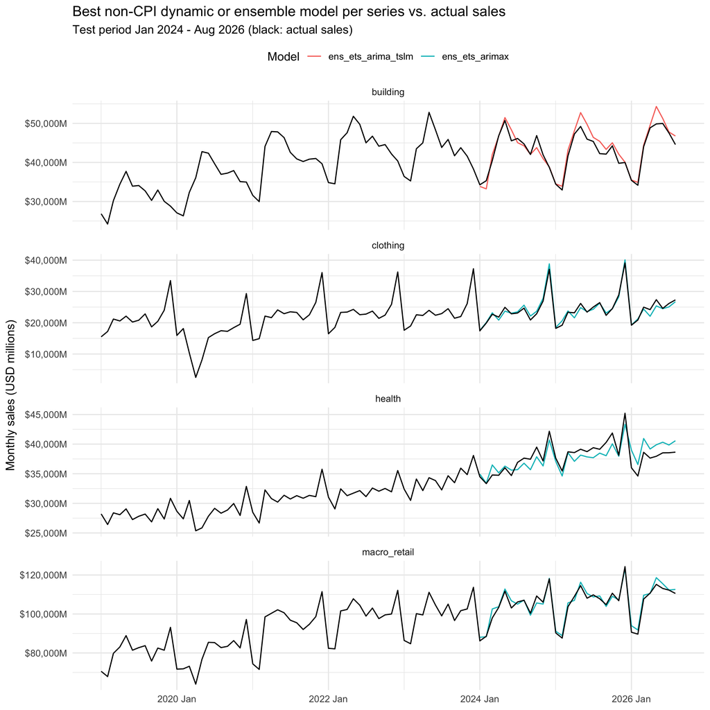

```r
dynamic_best <- comparison |>
  filter(Family %in% c("ARIMAX", "Fourier (DHR)", "Ensemble"), .model != "arimax_td_cpi") |>
  group_by(vertical) |>
  slice_min(RMSE, n = 1, with_ties = FALSE) |>
  ungroup()

fc_dynamic |>
  semi_join(dynamic_best, by = c("vertical", ".model")) |>
  autoplot(retail_ts |> filter(Month >= yearmonth("2019 Jan")), level = NULL) +
  facet_wrap(vars(vertical), scales = "free_y", ncol = 1) +
  scale_y_continuous(labels = dollar_format(suffix = "M")) +
  labs(title = "Best non-CPI dynamic or ensemble model per series vs. actual sales",
       subtitle = "Test period Jan 2024 - Aug 2026 (black: actual sales)",
       y = "Monthly sales (USD millions)", x = NULL, colour = "Model") +
  theme(legend.position = "top")
```

**Interpretation.**

**Recommendation for the presentation:** use the ETS + ARIMAX (trading days) ensemble as the main forecast for Clothing, Health, and Macro, and the three-model ensemble for Building, then confirm the ranking with the team’s rolling-origin cross-validation before finalizing. For Building, the automatic multiplicative ETS in the ETS section is also strong on its own and should be compared in that cross-validation.